# Math 421 - Midterm

## Instruction

The midterm has two components: the Rmarkdown notebook (html) and the presentation. We will do the presentation in class. Post both the notebook and the presentation on your Github page.

**The notebook:** The notebook should be created using `rmarkdown` or Quarto (like other assignments). The notebook should have a title.

**The Presentation:** Present your results in 5-10 minutes. To make the presentation using Rmarkdown, do the follows:

```
- In Rstudio -> File -> New File -> R markdown

- In the left panel, click to Presentation -> Click OK

- Now you have an Rmarkdown that can be knitted to be a html presentation
```

- You can also use the Rmd templates of the class slides.
- You can also use Quarto to create the presentation: *In Rstudio -> File -> New File -> Quarto Presentation…*
- You do not need to rerun all the codes for the presentation. For example, to show the model comparison, you just need to show the image of the model comparison instead of running all the models again.
- To inset an image in a slide, use `![](image.png)`
- To scale images, you can use `![](image.png){width="60%"}` or follow these below instructions.
  - https://bookdown.org/yihui/rmarkdown-cookbook/figure-size.html
  - http://zevross.com/blog/2017/06/19/tips-and-tricks-for-working-with-images-and-figures-in-r-markdown-documents/
- To turn off message and warning of a code cell, use: `{r, message=FALSE, warning=FALSE}` for the cell.

**What to present**:

- Present Part 2 - Visualization
- Present Question Question 4, 5 and 6 in Part 3.
- Present any errors/challenges you run into and how you fix/overcome them.

**Data:**

The data for the mid-term project is the Rhode Island Department of Health Hospital Discharge Data. Each row of the data presents a patient.

Link: https://drive.google.com/open?id=15QNBf6YYKocK2nNIfpKDer58kQnCPNZJ

**Notice**

- Since this is a large dataset, you could try to run the codes on the smaller dataset, which is a portion of the original dataset before running the codes on the original data. To create a random subset of the data you could use

```r
# find the number of rows of the data
n = nrow(df)

# subset 1000 rows of the data
df1 = df[sample(1:n, 1000), ]
```

## I. Data Wranggling

1. Download the data file `hdd0318cy.sas7bdat`.

The file is saved in my assignments folder.

```r
data_file <- "C:/Users/student/OneDrive - Bryant University/math421assigments/hdd0318cy.sas7bdat"
```

2. Use `read_sas` in library `haven` to read the data.

```r
required_vars <- c(
 "yod","payfix","pay_ub92","age","sex","raceethn","provider","moa",
 "yoa","mod","admtype","asource","preopday","los","service","icu",
 "ccu","dispub92","payer","drg","trandb","randbg","randbs","orr",
 "anes","seq","lab","dtest","ther","blood","phar","other","patcon",
 "bwght","total","tot","ecodub92","b_wt","pt_state","diag_adm",
 "ancilar","campus","er_fee","er_chrg","er_mode","obs_chrg",
 "obs_hour","psycchrg","nicu_day")

# Read the year column first. If the requested records are contiguous,
# read just that block and the assigned columns; otherwise read the assigned
# columns for the full file. This avoids loading millions of unused rows.
year_index <- haven::read_sas(data_file,col_select="yod")
rows_2018 <- which(year_index$yod==18)
stopifnot(length(rows_2018)>0)
if (all(diff(rows_2018)==1)) {
 raw_data <- haven::read_sas(data_file,skip=min(rows_2018)-1,
   n_max=length(rows_2018),col_select=all_of(required_vars))
} else {
 raw_data <- haven::read_sas(data_file,col_select=all_of(required_vars))
}
rm(year_index,rows_2018)
```

3. Filter the data to have only patients of the year 2018 (`yod=18`)

```r
df_2018 <- raw_data %>% filter(yod == 18)
rm(raw_data)
```

4. Select to work with only following variables:

```r
                      "yod", "payfix","pay_ub92","age",
                      "sex","raceethn","provider","moa",
                      "yoa","mod","admtype", "asource" ,
                      "preopday" ,"los", "service" , "icu","ccu",
                      "dispub92", "payer"  ,"drg","trandb",
                      "randbg","randbs","orr", "anes","seq",
                      "lab","dtest", "ther","blood","phar",
                      "other","patcon","bwght","total","tot" ,
                      "ecodub92","b_wt","pt_state","diag_adm","ancilar" ,
                      "campus","er_fee","er_chrg","er_mode","obs_chrg",
                      "obs_hour","psycchrg","nicu_day"
```

*Notice*: You may want to save the current data to your computer for easy access later. To save the data file use `write_csv(df, 'midterm.csv')`, for example. Also notice that, empty values in the data before writing to csv may turn to NAs later when you re-read the file.

```r
df_2018 <- df_2018 %>% select(all_of(required_vars))
dim(df_2018)
```

```
## [1] 131478     49
```

```r
str(df_2018)
```

```
## tibble [131,478 × 49] (S3: tbl_df/tbl/data.frame)
##  $ yod     : num [1:131478] 18 18 18 18 18 18 18 18 18 18 ...
##   ..- attr(*, "label")= chr " year of discharge  yy"
##  $ payfix  : num [1:131478] NA NA NA NA NA NA NA NA NA NA ...
##  $ pay_ub92: num [1:131478] 9 2 6 4 13 4 4 13 1 9 ...
##   ..- attr(*, "label")= chr " payer"
##   ..- attr(*, "format.sas")= chr "PAY_UB9Z"
##  $ age     : num [1:131478] 0 76 50 0 0 0 0 0 70 25 ...
##   ..- attr(*, "label")= chr " patient age at admission"
##  $ sex     : chr [1:131478] "1" "2" "2" "1" ...
##   ..- attr(*, "label")= chr " patient sex (1=M,2=F) alpha"
##   ..- attr(*, "format.sas")= chr "$SEX"
##  $ raceethn: chr [1:131478] "1" "1" "1" "7" ...
##   ..- attr(*, "label")= chr " patient race/ethnicity"
##   ..- attr(*, "format.sas")= chr "$RACEETH"
##  $ provider: chr [1:131478] "7214" "7214" "7214" "7214" ...
##   ..- attr(*, "label")= chr " provider"
##   ..- attr(*, "format.sas")= chr "$PROVID"
##  $ moa     : num [1:131478] 1 1 12 1 12 12 1 1 1 12 ...
##   ..- attr(*, "label")= chr " month of admission  mm"
##   ..- attr(*, "format.sas")= chr "MONTHNME"
##  $ yoa     : num [1:131478] 18 18 17 18 17 17 18 18 18 17 ...
##   ..- attr(*, "label")= chr " year of admission  yy"
##  $ mod     : num [1:131478] 1 1 1 1 1 1 1 1 1 1 ...
##   ..- attr(*, "label")= chr " month of discharge  mm"
##   ..- attr(*, "format.sas")= chr "MONTHNME"
##  $ admtype : chr [1:131478] "4" "3" "2" "4" ...
##   ..- attr(*, "label")= chr " admission type"
##   ..- attr(*, "format.sas")= chr "$ADMTYPE"
##  $ asource : chr [1:131478] "S" "1" "1" "S" ...
##   ..- attr(*, "label")= chr " admission source"
##   ..- attr(*, "format.sas")= chr "$ASOURCE"
##  $ preopday: num [1:131478] 2 0 -1 NA 2 0 NA NA 0 10 ...
##  $ los     : num [1:131478] 2 1 3 4 35 17 2 3 2 12 ...
##   ..- attr(*, "label")= chr " length of stay,in days for hosp[in hours for ED"
##  $ service : chr [1:131478] "00" "00" "00" "00" ...
##   ..- attr(*, "label")= chr " hospital service"
##   ..- attr(*, "format.sas")= chr "$SERVICE"
##  $ icu     : chr [1:131478] "000000" "000000" "000000" "000000" ...
##   ..- attr(*, "label")= chr " icu days"
```

[output cut: 40 more lines]

```
##   ..- attr(*, "label")= chr " total charges (numeric)"
##  $ ecodub92: chr [1:131478] "" "" "" "" ...
##   ..- attr(*, "label")= chr " ecode icd9 code"
##  $ b_wt    : chr [1:131478] "389" "000" "000" "397" ...
##  $ pt_state: chr [1:131478] "RI" "RI" "RI" "RI" ...
##  $ diag_adm: chr [1:131478] "Z3800" "C541" "C569" "Z3801" ...
##  $ ancilar : chr [1:131478] "00001253" "00040575" "00088735" "00000612" ...
##  $ campus  : chr [1:131478] "0" "0" "0" "0" ...
##  $ er_fee  : chr [1:131478] "00000000" "00000000" "00000000" "00000000" ...
##  $ er_chrg : chr [1:131478] "00000000" "00000000" "00000000" "00000000" ...
##  $ er_mode : chr [1:131478] "9" "9" "9" "9" ...
##  $ obs_chrg: chr [1:131478] "00000000" "00000000" "00000000" "00000000" ...
##  $ obs_hour: num [1:131478] 0 0 0 0 0 0 0 0 0 0 ...
##  $ psycchrg: chr [1:131478] "00000000" "00000000" "00000000" "00000000" ...
##  $ nicu_day: num [1:131478] NA NA NA NA 400 1700 NA NA NA NA ...
```

5. What are variables that have missing values?

```r
missing_report <- data.frame(
 variable = names(df_2018),
 missing = unname(colSums(is.na(df_2018))))
missing_report <- missing_report %>%
 mutate(percent = 100 * missing / nrow(df_2018))
show_table(filter(missing_report, missing > 0))
```

| variable | missing | percent |
| --- | --- | --- |
| payfix | 131478 | 100.00 |
| preopday | 60486 | 46.00 |
| obs_hour | 77343 | 58.83 |
| nicu_day | 124090 | 94.38 |

```r
# Check character blanks separately from NA.
blank_counts <- vapply(df_2018, function(x) {
 if (is.character(x)) sum(trimws(x) == "") else 0L
}, integer(1))
show_table(data.frame(variable = names(blank_counts)[blank_counts > 0],
 blanks = unname(blank_counts[blank_counts > 0])))
```

| variable | blanks |
| --- | --- |
| raceethn | 3950 |
| admtype | 1 |
| asource | 6 |
| bwght | 131478 |
| ecodub92 | 104339 |
| pt_state | 3 |
| diag_adm | 50 |
| er_mode | 12158 |

The columns with NA values are `payfix`, `preopday`, `obs_hour`, and `nicu_day`. Blank character values are shown separately. For modeling, I remove blank race and admission-type values as required in Part III.

6. Remove all variables with missing values.

```r
removed_vars <- missing_report$variable[missing_report$missing > 0]
df <- df_2018 %>% select(-all_of(removed_vars))
stopifnot(!anyNA(df))
dim(df)
```

```
## [1] 131478     45
```

There are 131,478 records left and 45 variables. Removing columns does not remove any rows.

7. Refer to the data description in the file `HDD2015-18cy6-20-19.docx`, which variable recording the month of admission?, which variable recording the month of discharge?

The codebook defines **moa** as month of admission and **mod** as month of discharge. Both use month numbers 1–12. Sex is a character code: 1 is male and 2 is female. Age is recorded at admission. The codebook says ages 90+ are grouped, but the actual file contains ages through 110. I retain the recorded ages rather than imposing an undocumented recoding; this mismatch is a limitation of interpreting age statistics.

```r
provider_names <- c(
 "7201"="Newport", "7202"="St. Joseph Health Services of RI",
 "7203"="Memorial", "7204"="Miriam", "7205"="Rhode Island Hospital",
 "7206"="Roger Williams", "7209"="South County", "7210"="Kent County",
 "7211"="Westerly", "7212"="Rehab of RI", "7213"="Landmark Medical Center",
 "7214"="Women and Infants", "7215"="Bradley", "7216"="Butler")
df <- df %>% mutate(
 sex=trimws(as.character(sex)),
 provider_name=unname(provider_names[as.character(provider)]),
 admission_month=factor(moa, levels=1:12, labels=month.abb),
 sex_label=factor(sex, levels=c("1","2"), labels=c("Male","Female")))
stopifnot(!anyNA(df$provider_name))
```

Teenagers are ages 13–19 inclusive. Every ranking below preserves ties.

8. Which month admitted the most number of patients? Which month admitted the most number of male patients?

```r
admissions <- df %>% count(moa, admission_month, name="admissions")
male_admissions <- df %>% filter(sex=="1") %>%
  count(moa, admission_month, name="male_admissions")
show_table(admissions %>% slice_max(admissions, n=1))
```

| moa | admission_month | admissions |
| --- | --- | --- |
| 10 | Oct | 11408 |

```r
show_table(male_admissions %>% slice_max(male_admissions, n=1))
```

| moa | admission_month | male_admissions |
| --- | --- | --- |
| 10 | Oct | 5164 |

These are counts among the 2018 discharge cohort, grouped by admission month, rather than a complete census of all admissions occurring in 2018.

9. Which month has the most number of teenage female patients?

```r
teen_female <- df %>% filter(sex=="2", age>=13, age<=19) %>%
  count(moa, admission_month, name="teen_female_records")
show_table(teen_female %>% slice_max(teen_female_records, n=1))
```

| moa | admission_month | teen_female_records |
| --- | --- | --- |
| 3 | Mar | 226 |

10. Which provider has the most number of female patients in October?

```r
female_oct <- df %>% filter(sex=="2", moa==10) %>%
  count(provider, provider_name, name="female_records")
show_table(female_oct %>% slice_max(female_records, n=1))
```

| provider | provider_name | female_records |
| --- | --- | --- |
| 7205 | Rhode Island Hospital | 1517 |

11. Are female patients older than male patients, on average?

```r
age_sex <- df %>% filter(sex %in% c("1","2")) %>% group_by(sex_label) %>%
  summarise(n=n(), mean_age=mean(age), .groups="drop")
show_table(age_sex)
```

| sex_label | n | mean_age |
| --- | --- | --- |
| Male | 58799 | 51.50 |
| Female | 72675 | 50.86 |

```r
age_difference <- age_sex$mean_age[age_sex$sex_label=="Female"] -
                  age_sex$mean_age[age_sex$sex_label=="Male"]
```

Female mean recorded age minus male mean recorded age is -0.63 years. Female records are therefore younger on average in this cohort. This is a descriptive comparison; differences in provider and service mix can contribute. The codebook’s age-grouping statement disagrees with the observed values, so these are averages of the recorded ages.

12. Calculate the average age of patients by months. Which month has the oldest patients on average age?

```r
age_month <- df %>% group_by(moa, admission_month) %>%
  summarise(n=n(), mean_age=mean(age), .groups="drop")
show_table(age_month)
```

| moa | admission_month | n | mean_age |
| --- | --- | --- | --- |
| 1 | Jan | 11309 | 51.79 |
| 2 | Feb | 10259 | 51.21 |
| 3 | Mar | 11073 | 51.10 |
| 4 | Apr | 11174 | 51.39 |
| 5 | May | 11404 | 50.64 |
| 6 | Jun | 10690 | 51.52 |
| 7 | Jul | 10962 | 51.32 |
| 8 | Aug | 11199 | 50.93 |
| 9 | Sep | 10666 | 50.57 |
| 10 | Oct | 11408 | 50.85 |
| 11 | Nov | 10636 | 50.97 |
| 12 | Dec | 10698 | 51.48 |

```r
show_table(age_month %>% slice_max(mean_age,n=1))
```

| moa | admission_month | n | mean_age |
| --- | --- | --- | --- |
| 1 | Jan | 11309 | 51.79 |

13. What is the name of the provider that has the highest total charge?

I interpret this as **summed charges across all records for a provider**. For clarity, I also show the provider with the largest individual charge.

```r
provider_charge <- df %>% group_by(provider, provider_name) %>%
  summarise(n=n(), summed_charges=sum(tot), mean_charge=mean(tot),
            .groups="drop")
show_table(provider_charge %>% slice_max(summed_charges,n=1))
```

| provider | provider_name | n | summed_charges | mean_charge |
| --- | --- | --- | --- | --- |
| 7205 | Rhode Island Hospital | 36693 | 1788373499 | 48738.82 |

```r
show_table(df %>% slice_max(tot,n=1) %>% select(provider_name,tot))
```

| provider_name | tot |
| --- | --- |
| Women and Infants | 3402056 |

14. What is the name of the provider that has the least total charge for teenage male on average?

```r
teen_male_charge <- df %>% filter(sex=="1", age>=13, age<=19) %>%
  group_by(provider, provider_name) %>%
  summarise(n=n(), mean_charge=mean(tot), .groups="drop")
show_table(teen_male_charge %>% slice_min(mean_charge,n=1))
```

| provider | provider_name | n | mean_charge |
| --- | --- | --- | --- |
| 7206 | Roger Williams | 9 | 10360.44 |

Providers with no teenage male records are not assigned a zero average. The subgroup count helps assess how stable each average may be.

15. Create a season (Spring, Summer, Fall, Winter) variable. Calculate the length of stays by season. Which season has the longest length of stays on average?

I use admission month to define Spring as March–May, Summer as June–August, Fall as September–November, and Winter as December–February.

```r
df <- df %>% mutate(
 season = case_when(
   moa %in% 3:5 ~ "Spring",
   moa %in% 6:8 ~ "Summer",
   moa %in% 9:11 ~ "Fall",
   moa %in% c(12, 1, 2) ~ "Winter"),
 season = factor(season, levels = c("Spring", "Summer", "Fall", "Winter")))
```

```r
season_stay <- df %>% group_by(season) %>%
  summarise(n=n(), mean_los=mean(los), median_los=median(los),.groups="drop")
show_table(season_stay)
```

| season | n | mean_los | median_los |
| --- | --- | --- | --- |
| Spring | 33651 | 4.84 | 3 |
| Summer | 32851 | 4.96 | 3 |
| Fall | 32710 | 4.96 | 3 |
| Winter | 32266 | 4.93 | 3 |

```r
show_table(season_stay %>% slice_max(mean_los,n=1))
```

| season | n | mean_los | median_los |
| --- | --- | --- | --- |
| Summer | 32851 | 4.96 | 3 |

16. On average, how much a 20 year-old male get charged for staying 1 day in the Fall season?

The literal interpretation is the average **total charge among one-day stays** for this subgroup. It is not an estimate of an incremental day of care.

```r
one_day_fall <- df %>% filter(age==20, sex=="1", season=="Fall",los==1) %>%
  summarise(n=n(), mean_charge=if(n()>0) mean(tot) else NA_real_)
show_table(one_day_fall)
```

| n | mean_charge |
| --- | --- |
| 6 | 16511 |

```r
# Alternative daily-rate interpretation, explicitly distinguished:
daily_fall <- df %>% filter(age==20, sex=="1",season=="Fall",los>0) %>%
  summarise(n=n(), mean_individual_daily_charge=mean(tot/los),
            charge_per_total_day=sum(tot)/sum(los))
show_table(daily_fall)
```

| n | mean_individual_daily_charge | charge_per_total_day |
| --- | --- | --- |
| 80 | 6435.65 | 5783.93 |

17. Write a paragraph to summarize the section and give your comments on the results. You could do some other calculations to support your points.

The analysis retained 131,478 discharge records after restricting to 2018 and removing columns with NA values. Recorded mean age differs between female and male records by 0.63 years. The highest aggregate provider charge is $1,788,373,499.00, recorded by Rhode Island Hospital. The longest average stay occurs in Summer. These results describe utilization and billing in the discharge cohort; they do not establish that sex, season, or provider causes a difference. Aggregate charges also depend on record volume and case mix.

## II. Data Visualization

Continue with the data from part I.

1. Provides at least 10 meaningful plots. Comments on the plots. All plots should have title, caption, appropriate labels on x and y-axis

```r
caption_text <- "Source: RI DOH public-use data; 2018 discharge cohort."
theme_set(theme_minimal(base_size=12))
plots <- list(
 monthly = ggplot(admissions,aes(admission_month,admissions)) +
  geom_col(fill="steelblue") + labs(title="Admissions by month",x="Admission month",
   y="Discharge records",caption=caption_text),
 monthly_sex = df %>% filter(!is.na(sex_label)) %>% count(admission_month,sex_label) %>%
  ggplot(aes(admission_month,n,fill=sex_label)) + geom_col(position="dodge") +
  labs(title="Monthly admissions by sex",x="Admission month",y="Discharge records",
       fill="Sex",caption=caption_text),
 age = ggplot(df,aes(age)) + geom_histogram(binwidth=5,fill="steelblue",color="white") +
  labs(title="Recorded age at admission",x="Recorded age (years)",y="Discharge records",
       caption=paste(caption_text,"Recorded ages retained; codebook grouping differs.")),
 age_sex = df %>% filter(!is.na(sex_label)) %>% ggplot(aes(sex_label,age,fill=sex_label)) +
  geom_boxplot(show.legend=FALSE) + labs(title="Age by sex",x="Sex",y="Recorded age (years)",
  caption=caption_text),
 provider = df %>% count(provider_name) %>% ggplot(aes(reorder(provider_name,n),n)) +
  geom_col(fill="steelblue") + coord_flip() + labs(title="Records by provider",
  x="Provider",y="Discharge records",caption=caption_text),
 charges = ggplot(df,aes(tot)) + geom_histogram(bins=50,fill="steelblue",color="white") +
  scale_x_continuous(trans=scales::pseudo_log_trans(base=10),
   breaks=c(0,100,1000,10000,100000,1000000),labels=scales::label_dollar(scale_cut=scales::cut_short_scale())) +
  labs(title="Distribution of total charges",x="Total charge (dollars; pseudo-log scale)",
  y="Discharge records",caption=paste(caption_text,"Pseudo-log includes zero charges.")),
 charge_provider = ggplot(df,aes(provider_name,tot)) + geom_boxplot(outlier.alpha=.1) +
  scale_y_continuous(trans=scales::pseudo_log_trans(base=10),
   breaks=c(0,100,1000,10000,100000,1000000),labels=scales::label_dollar(scale_cut=scales::cut_short_scale())) +
  coord_flip() + labs(title="Charges vary across providers",x="Provider",
  y="Total charge (dollars; pseudo-log scale)",caption=caption_text),
 season = ggplot(df,aes(season,los,fill=season)) + geom_boxplot(show.legend=FALSE,outlier.alpha=.1) +
  scale_y_continuous(trans=scales::pseudo_log_trans(base=10),breaks=c(0,1,3,7,14,30,90,365)) +
  labs(title="Length of stay by admission season",x="Admission season",
  y="Stay (days; pseudo-log scale)",caption=caption_text),
 stay_charge = ggplot(df,aes(los,tot)) + geom_point(alpha=.06,size=.5) +
  scale_x_continuous(trans=scales::pseudo_log_trans(base=10),breaks=c(0,1,3,7,14,30,90,365)) +
  scale_y_continuous(trans=scales::pseudo_log_trans(base=10),
   breaks=c(0,100,1000,10000,100000,1000000),labels=scales::label_dollar(scale_cut=scales::cut_short_scale())) +
  labs(title="Length of stay and total charges",x="Stay (days; pseudo-log scale)",
  y="Total charge (dollars; pseudo-log scale)",caption=caption_text),
 age_month = ggplot(age_month,aes(moa,mean_age)) + geom_line() + geom_point(size=2) +
  scale_x_continuous(breaks=1:12,labels=month.abb) + labs(title="Average recorded age by admission month",
  x="Admission month",y="Mean recorded age (years)",caption=caption_text)
)
for (nm in names(plots)) ggsave(file.path("midterm_assets",paste0(nm,".png")),
                               plots[[nm]],width=9,height=5,dpi=120)
```

### 1. Monthly counts

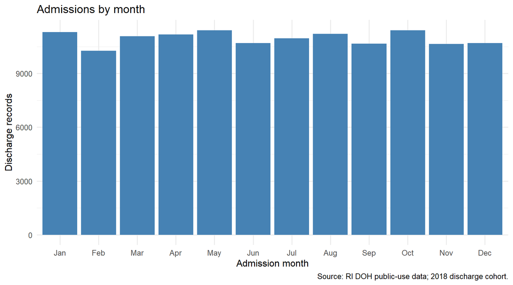

```r
plots$monthly
```

The highest count is 11408 in Oct. These are counts, not rates adjusted for the number of days in a month.

### 2. Monthly counts by sex

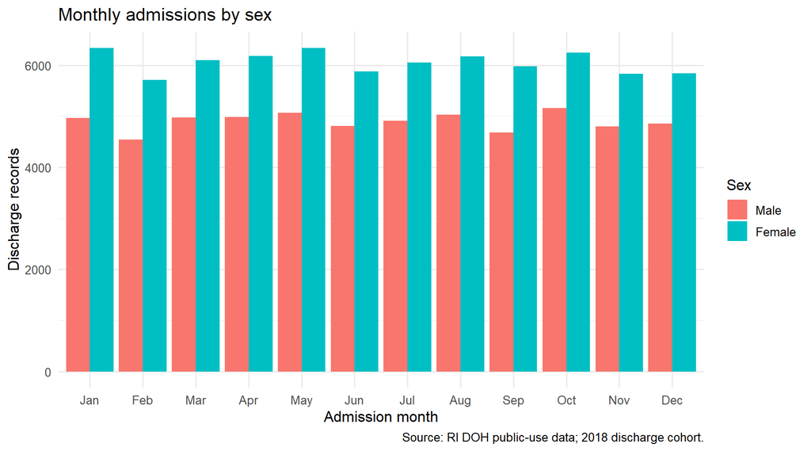

```r
plots$monthly_sex
```

There are 72675 female and 58799 male records. The grouped bars show whether the difference persists across admission months. They reflect hospital utilization rather than sex-specific population risk.

### 3. Age histogram

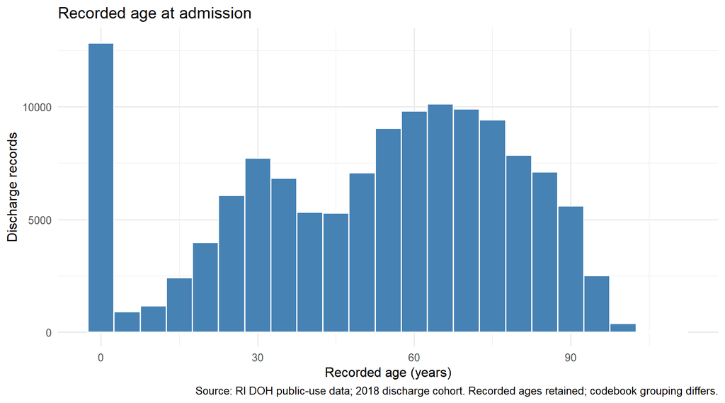

```r
plots$age
```

Median recorded age is 56 years. The youngest ages include newborn care. Recorded ages reach 110, despite the codebook’s statement about grouping ages 90+; the plot retains those recorded values.

### 4. Age by sex

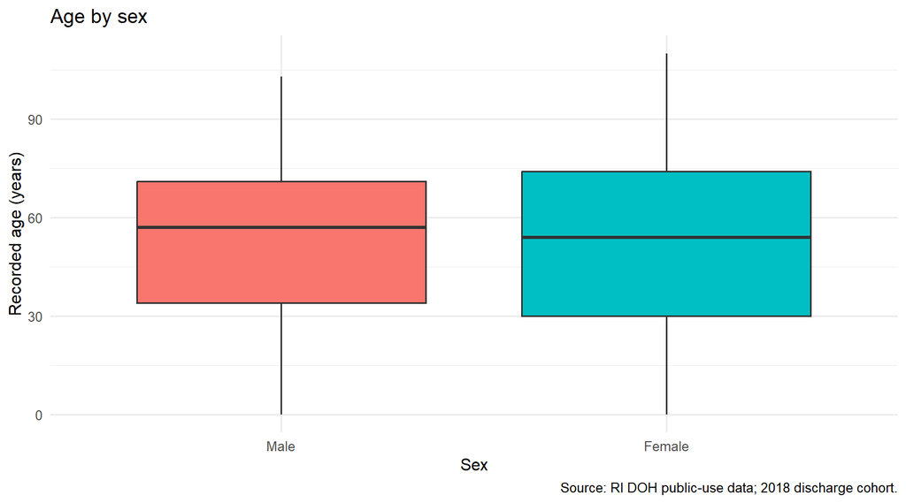

```r
plots$age_sex
```

The boxes compare medians and spread, complementing the mean difference of -0.63 years in Part I. A mean alone does not describe the full distribution or account for different service mixes.

### 5. Provider volume

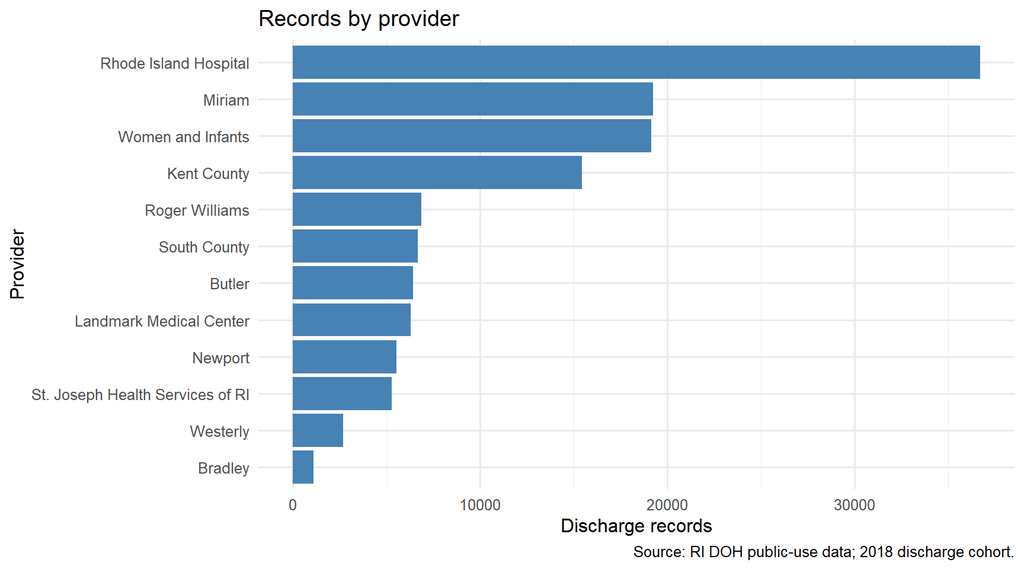

```r
plots$provider
```

Rhode Island Hospital has the most records. Provider volume is important context for interpreting aggregate charges.

### 6. Total charge histogram

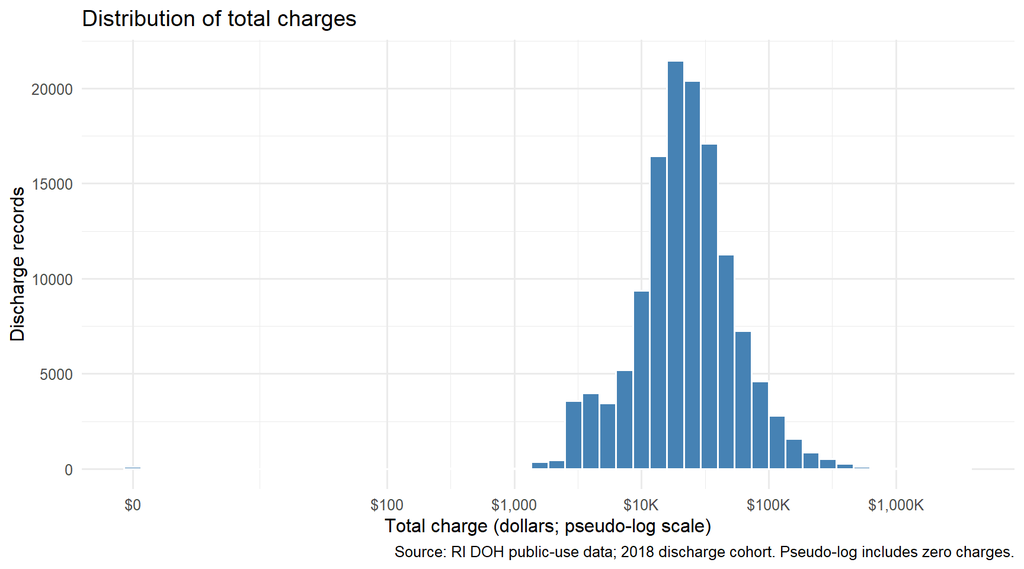

```r
plots$charges
```

Mean charges are $34,317.18, versus a median of $21,854.00. Their difference measures the influence of the upper tail. Pseudo-log scaling makes a wide range of values visible.

### 7. Charges by provider

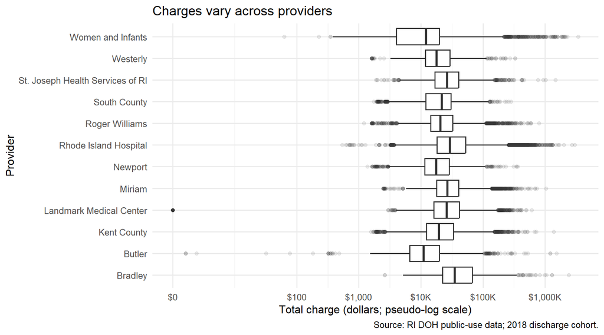

```r
plots$charge_provider
```

The lowest and highest provider mean charges are $17,781.83 and $69,945.55. Differences may reflect case mix, specialties, and length of stay, rather than price alone.

### 8. Length of stay by season

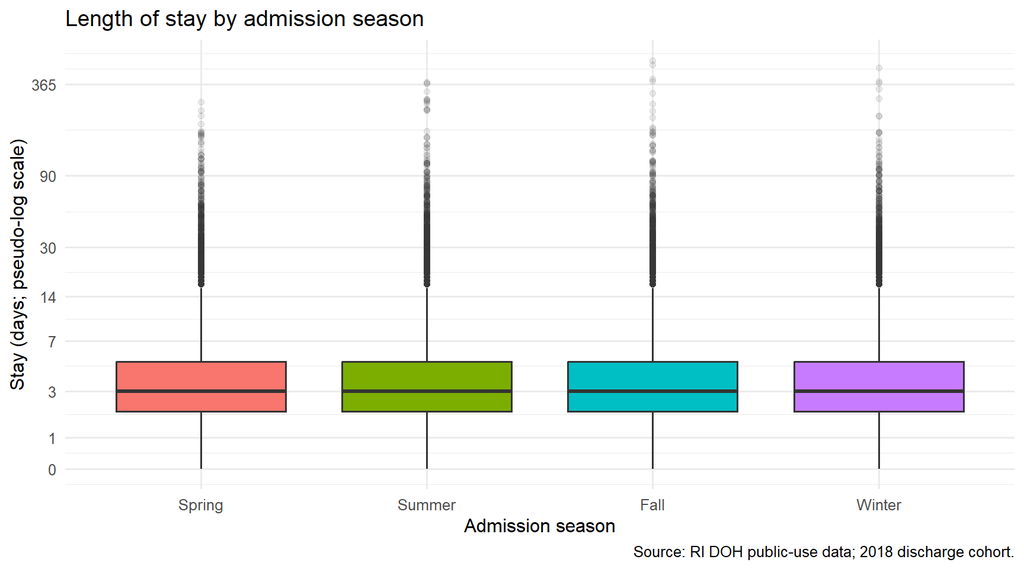

```r
plots$season
```

Seasonal mean stays range from 4.84 to 4.96 days. The boxplots also show how within-season variability compares with these differences in means.

### 9. Length of stay versus charge

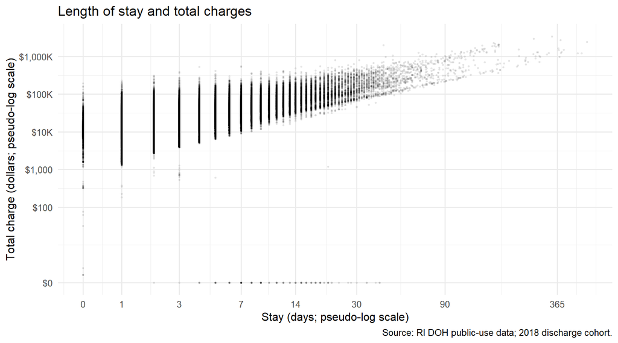

```r
plots$stay_charge
```

The Pearson correlation is 0.786 on the original scales. The association is descriptive, and charge variation at similar stays can reflect different services and conditions.

### 10. Mean age by admission month

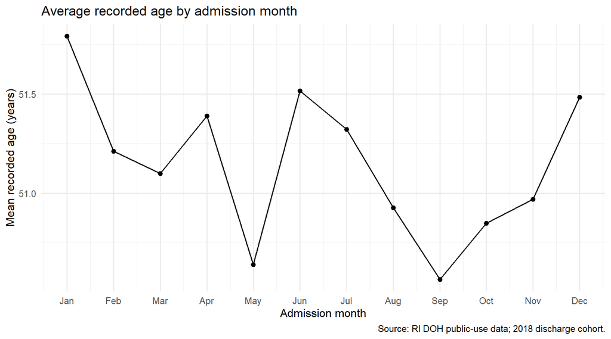

```r
plots$age_month
```

Monthly means range from 50.57 to 51.79 recorded years. The axis displays actual means; it does not imply changes for the same patients over time.

2. Make an animation plot.

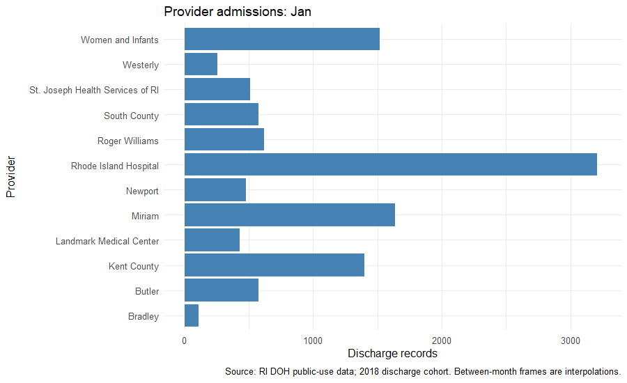

```r
animation_data <- df %>% count(moa,provider_name) %>%
  complete(moa=1:12,provider_name,fill=list(n=0)) %>%
  mutate(month=factor(moa,levels=1:12,labels=month.abb))
animated_plot <- ggplot(animation_data,aes(provider_name,n,group=provider_name)) +
  geom_col(fill="steelblue") + coord_flip() +
  labs(title="Provider admissions: {closest_state}",x="Provider",y="Discharge records",
       caption=paste(caption_text,"Between-month frames are interpolations.")) +
  transition_states(month,transition_length=1,state_length=2,wrap=FALSE)
animation <- animate(animated_plot,nframes=96,fps=8,width=900,height=550,units="px",res=96,
                     renderer=gifski_renderer())
anim_save("midterm_assets/provider_month.gif",animation=animation)
knitr::include_graphics("midterm_assets/provider_month.gif")
```

The animation compares monthly provider counts on a fixed scale. Intermediate frames are visual transitions and should not be interpreted as observed days.

3. Write a paragraph to summarize the section and give your comments on the results.

The figures describe monthly volume, age, provider mix, stay duration, and charges. Mean charge is $34,317.18, while median charge is $21,854.00; reporting both helps describe the distribution. Provider counts and charge distributions should be considered together. The stay–charge relationship motivates retrospective classification, but neither these plots nor the models establish causal effects.

## III. Predictive Models

Continue with the data from part I. Make sure you do not have any missing values in the data. Use the follows as the target and input variables:

*Target Variable*: Create the target variable taking value of

- `low` if the total charge of a patient (`tot`) is smaller than the median of the total charge, and
- `high` otherwise.

*Input Variables*:

- “age”,“sex”,“raceethn”,“provider”,“moa”,“mod”,“admtype”,“campus”, ‘los’
1. Use `filter` function to filter out rows where `raceethn==''` or `admtype==''`. Make sure all the categorical variables are factor, numeric variables are numeric. Set Training : Testing Split = 10 : 90

```r
inputs <- c("age","sex","raceethn","provider","moa","mod","admtype","campus","los")
stopifnot(all(c(inputs,"tot") %in% names(df)))
# Follow the assignment: define the median on the cleaned Part I cohort,
# before filtering blank race/admission-type records.
charge_median <- median(df$tot)
model_base <- df %>% mutate(target=ifelse(tot<charge_median,"low","high")) %>%
  filter(trimws(as.character(raceethn))!="", trimws(as.character(admtype))!="")
categorical <- c("sex","raceethn","provider","moa","mod","admtype","campus")
model_data <- model_base %>% select(all_of(inputs),target) %>%
  mutate(across(all_of(categorical), ~factor(trimws(as.character(.x)))),
         across(c(age,los),as.numeric),target=factor(target,levels=c("low","high")))
stopifnot(!anyNA(model_data))
set.seed(421)
split_index <- createDataPartition(model_data$target,p=.10,list=FALSE)
train_data <- model_data[split_index,]
test_data <- model_data[-split_index,]
show_table(data.frame(set=c("Training","Testing"),n=c(nrow(train_data),nrow(test_data))))
```

| set | n |
| --- | --- |
| Training | 12753 |
| Testing | 114774 |

```r
show_table(as.data.frame(table(model_data$target)))
```

| Var1 | Freq |
| --- | --- |
| low | 62947 |
| high | 64580 |

The charge threshold is $21,854.00. Equality goes to high. The assigned inputs include discharge month and realized stay duration; therefore, this is **retrospective charge classification**, not a prediction available at admission. Charge amounts themselves are excluded as predictors.

2. Train a decision tree using `rpart`. Plot the decision tree. Plot the variable importance ranked by the tree.

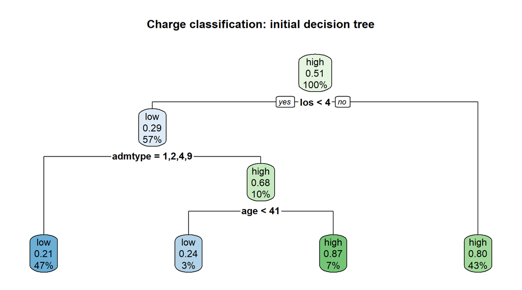

```r
tree <- rpart(target~.,data=train_data,method="class",
              control=rpart.control(maxdepth=3))
rpart.plot(tree,main="Charge classification: initial decision tree")
```

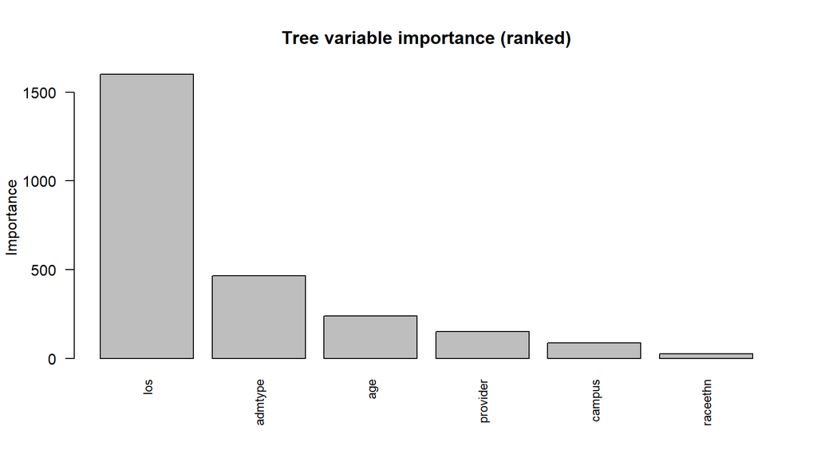

```r
importance <- sort(tree$variable.importance,decreasing=TRUE)
if (length(importance)>0) {
 barplot(importance,las=2,cex.names=.8,main="Tree variable importance (ranked)",
         ylab="Importance")
} else {
 plot.new(); title("Tree made no splits; no ranked importance available")
}
```

Importance describes predictive use in this tree and does not measure causation.

3. Using caret for this question. Set `Training Control` to be: Use Cross-Validation of 5 folds across all models. Train & tune at least 2 different models (i.e. two different values for `method=` in the train function of caret). Plot the hyper-parameter tuning plots for each model.

Both models use the same five training folds. I tune tree depth for `rpart2` and the number of candidate predictors and minimum node size for `ranger`. Model selection uses training cross-validation, not test accuracy.

```r
fit_and_compare <- function(training,testing,seed) {
 set.seed(seed)
 folds <- createFolds(training$target,k=5,returnTrain=TRUE)
 ctrl <- trainControl(method="cv",number=5,index=folds,allowParallel=FALSE)
 set.seed(seed)
 tuned_tree <- train(target~.,data=training,method="rpart2",metric="Accuracy",
                     trControl=ctrl,tuneGrid=expand.grid(maxdepth=2:6))
 set.seed(seed)
 tuned_forest <- train(target~.,data=training,method="ranger",metric="Accuracy",
   trControl=ctrl,num.trees=300,num.threads=2,
   tuneGrid=expand.grid(mtry=c(2,4,8),splitrule="gini",min.node.size=c(5,20)))
 models <- list(Tree=tuned_tree,Forest=tuned_forest)
 comparison <- resamples(models)
 # Each caret object selects its best setting using mean CV accuracy.
 scores <- vapply(models,function(m) max(m$results$Accuracy,na.rm=TRUE),numeric(1))
 stopifnot(all(is.finite(scores)), all(vapply(models,function(m)
    nrow(m$resample)==5 && all(is.finite(m$resample$Accuracy)),logical(1))))
 selected <- names(which.max(scores))
 final_model <- models[[selected]]
 prediction <- predict(final_model,newdata=testing)
 cm <- confusionMatrix(prediction,testing$target,positive=levels(testing$target)[2])
 list(models=models,comparison=comparison,scores=scores,selected=selected,
      final_model=final_model,cm=cm)
}
```

```r
charge_results <- fit_and_compare(train_data,test_data,421)
```

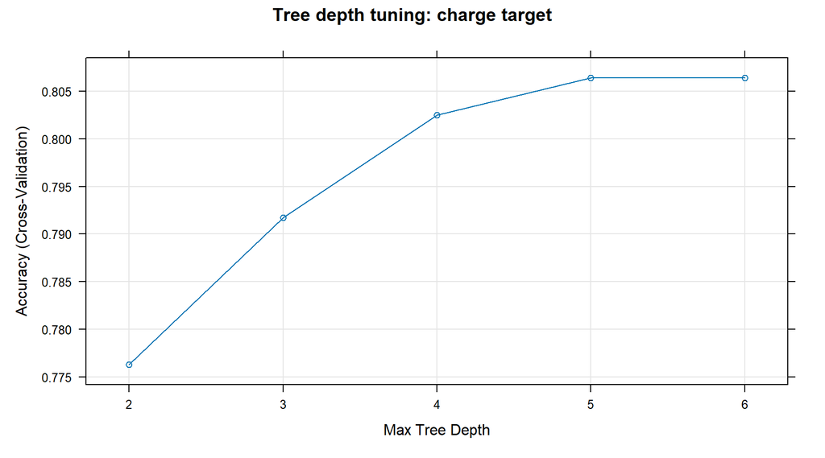

```r
plot(charge_results$models$Tree, main = "Tree depth tuning: charge target")
```

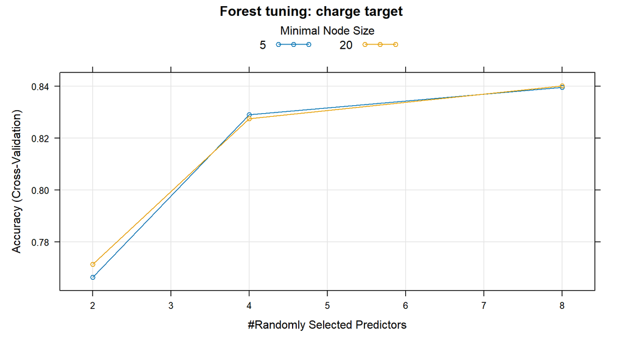

```r
plot(charge_results$models$Forest, main = "Forest tuning: charge target")
```

4. Plot the comparison of the models in 3.

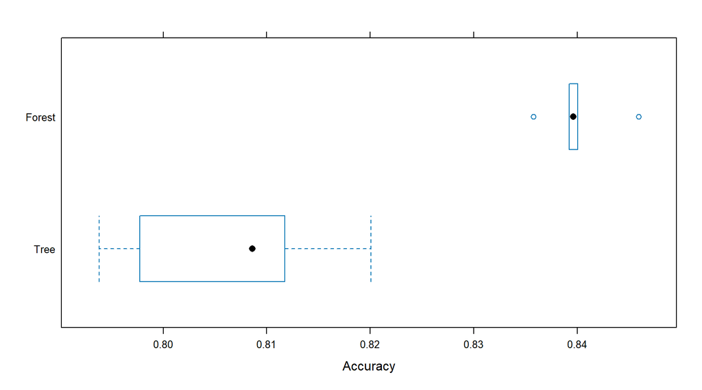

```r
bwplot(charge_results$comparison, metric = "Accuracy")
```

```r
show_table(data.frame(
 model = names(charge_results$scores),
 mean_cv_accuracy = unname(charge_results$scores)))
```

| model | mean_cv_accuracy |
| --- | --- |
| Tree | 0.81 |
| Forest | 0.84 |

```r
png("midterm_assets/charge_model_comparison.png", width=1000, height=600)
print(bwplot(charge_results$comparison, metric="Accuracy"))
dev.off()
```

5. What is your final selection for the model? Test the accuracy of your final model on the test data.

```r
charge_results$final_model$bestTune
```

```
##   mtry splitrule min.node.size
## 6    8      gini            20
```

```r
charge_results$cm
```

```
## Confusion Matrix and Statistics
##
##           Reference
## Prediction   low  high
##       low  48928 11065
##       high  7724 47057
##
##                Accuracy : 0.8363
##                  95% CI : (0.8341, 0.8384)
##     No Information Rate : 0.5064
##     P-Value [Acc > NIR] : < 2.2e-16
##
##                   Kappa : 0.6728
##
##  Mcnemar's Test P-Value : < 2.2e-16
##
##             Sensitivity : 0.8096
##             Specificity : 0.8637
##          Pos Pred Value : 0.8590
##          Neg Pred Value : 0.8156
##              Prevalence : 0.5064
##          Detection Rate : 0.4100
##    Detection Prevalence : 0.4773
##       Balanced Accuracy : 0.8366
##
##        'Positive' Class : high
##
```

The selected charge model is **Forest**, chosen by the largest mean cross-validation accuracy. Its held-out accuracy is **83.63%**, compared with a majority-class baseline of 50.64%. Sensitivity for high charges is 0.81 and specificity is 0.864.

6. Create another `target` variable (binary), decide the input variables and redo 1 to 5.

The second binary outcome is **long** when `los > 7` and **short** otherwise. Its inputs are age, sex, race/ethnicity, provider, admission month, admission type, and campus. Length of stay, discharge month, charges, and the first target are excluded. This avoids directly feeding the answer into the model.

```r
second_inputs <- c("age","sex","raceethn","provider","moa","admtype","campus")
second_data <- model_base %>% select(all_of(second_inputs),los) %>%
 mutate(target=factor(ifelse(los>7,"long","short"),levels=c("short","long"))) %>%
 select(-los) %>%
 mutate(across(all_of(setdiff(second_inputs,"age")),~factor(trimws(as.character(.x)))),
        age=as.numeric(age))
stopifnot(!anyNA(second_data))
set.seed(422)
second_split <- createDataPartition(second_data$target,p=.10,list=FALSE)
second_train <- second_data[second_split,]
second_test <- second_data[-second_split,]
show_table(as.data.frame(table(second_data$target)))
```

| Var1 | Freq |
| --- | --- |
| short | 108735 |
| long | 18792 |

```r
show_table(data.frame(set=c("Training","Testing"),n=c(nrow(second_train),nrow(second_test))))
```

| set | n |
| --- | --- |
| Training | 12754 |
| Testing | 114773 |

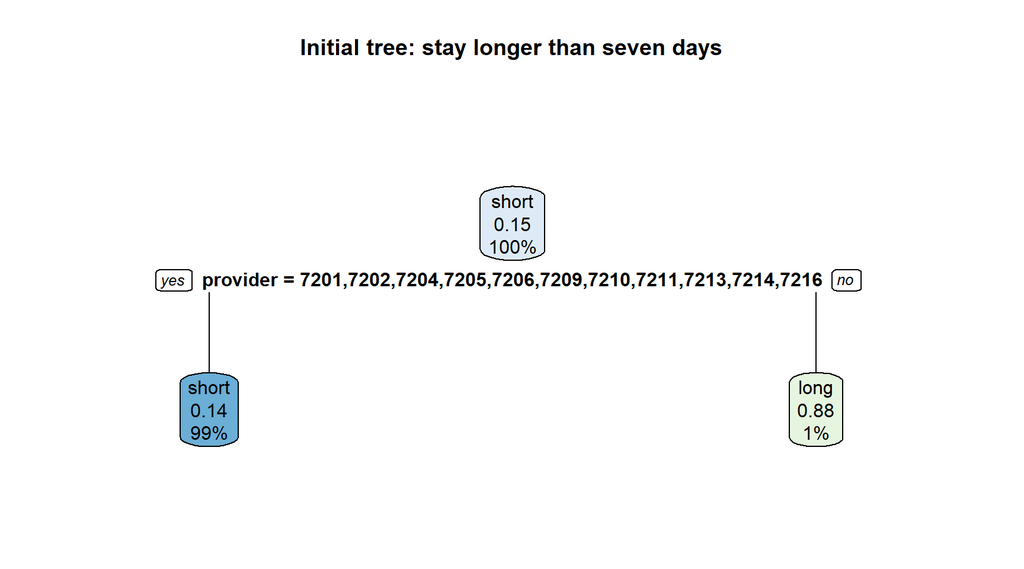

```r
second_tree <- rpart(target~.,data=second_train,method="class",
                     control=rpart.control(maxdepth=3))
rpart.plot(second_tree,main="Initial tree: stay longer than seven days")
```

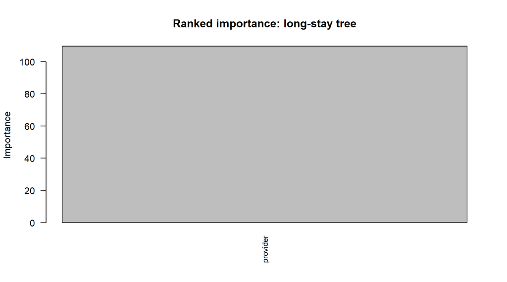

```r
second_importance <- sort(second_tree$variable.importance,decreasing=TRUE)
if (length(second_importance)>0) barplot(second_importance,las=2,cex.names=.8,
 main="Ranked importance: long-stay tree",ylab="Importance")
```

```r
stay_results <- fit_and_compare(second_train,second_test,422)
```

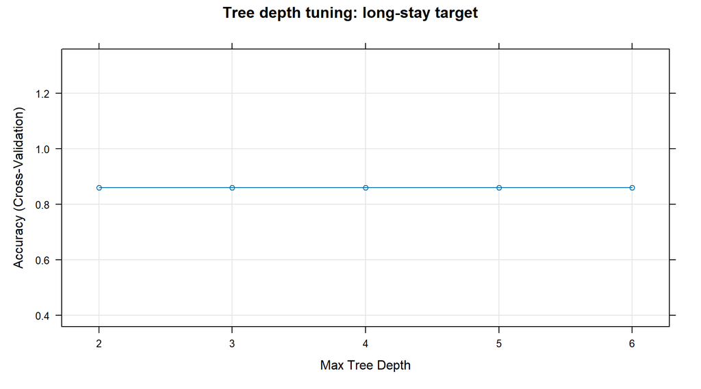

```r
plot(stay_results$models$Tree,main="Tree depth tuning: long-stay target")
```

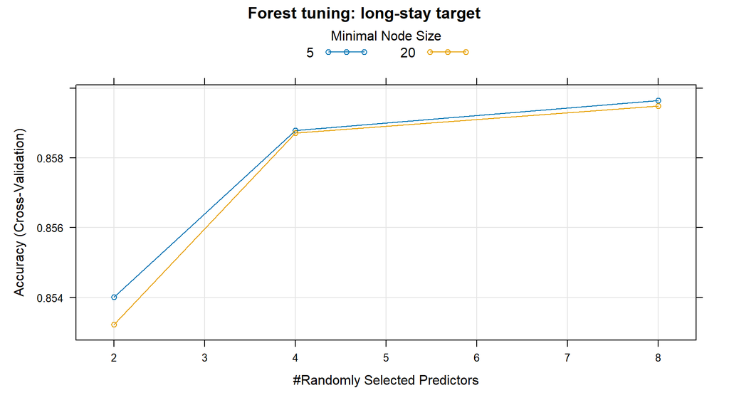

```r
plot(stay_results$models$Forest,main="Forest tuning: long-stay target")
```

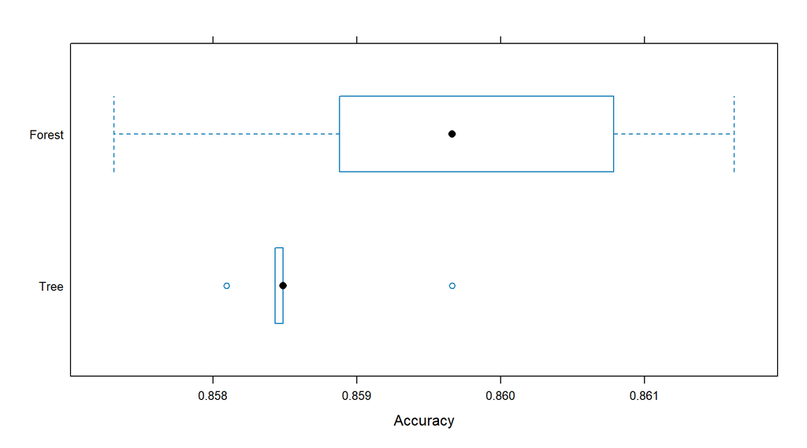

```r
bwplot(stay_results$comparison,metric="Accuracy")
```

```r
show_table(data.frame(model=names(stay_results$scores),
                     mean_cv_accuracy=unname(stay_results$scores)))
```

| model | mean_cv_accuracy |
| --- | --- |
| Tree | 0.86 |
| Forest | 0.86 |

```r
stay_results$final_model$bestTune
```

```
##   mtry splitrule min.node.size
## 5    8      gini             5
```

```r
stay_results$cm
```

```
## Confusion Matrix and Statistics
##
##           Reference
## Prediction short  long
##      short 97229 15492
##      long    632  1420
##
##                Accuracy : 0.8595
##                  95% CI : (0.8575, 0.8615)
##     No Information Rate : 0.8526
##     P-Value [Acc > NIR] : 2.056e-11
##
##                   Kappa : 0.1218
##
##  Mcnemar's Test P-Value : < 2.2e-16
##
##             Sensitivity : 0.08396
##             Specificity : 0.99354
##          Pos Pred Value : 0.69201
##          Neg Pred Value : 0.86256
##              Prevalence : 0.14735
##          Detection Rate : 0.01237
##    Detection Prevalence : 0.01788
##       Balanced Accuracy : 0.53875
##
##        'Positive' Class : long
##
```

```r
png("midterm_assets/stay_model_comparison.png",width=1000,height=600)
print(bwplot(stay_results$comparison,metric="Accuracy"))
dev.off()
```

The selected long-stay model is **Forest**. Held-out accuracy is **85.95%**, versus the majority-class baseline of 85.26%. Long-stay sensitivity is 0.084; specificity is 0.994; balanced accuracy is 0.539. These are important alongside accuracy because the classes may be imbalanced.

The model misses approximately 91.6% of actual long stays. With sensitivity this low, the selected model is a poor tool for identifying long stays, even though its overall accuracy looks high. Improving long-stay detection would require a new training-only analysis of class imbalance, model settings, and an appropriate selection metric, followed by evaluation on new held-out data. This test set should not be reused for tuning.

7. Write a paragraph to summarize the section and give your comments on the results.

Two different caret methods were tuned for each outcome using five-fold cross-validation within the assigned 10% training subset. Charge classification selected Forest, while long-stay classification selected Forest. Test performance is reported against majority-class baselines, with sensitivity and specificity showing which outcomes are harder to detect. These are descriptive predictive models, not causal models. Repeated stays may belong to the same people; without person identifiers we cannot guarantee patient-independent train/test sets. A random split within 2018 also does not establish performance in a future year or another state.

## Challenges, reproducibility, and presentation notes

- The source file spans 2003–2018. Reading its year index first and importing only the relevant block saves memory without sampling the analysis data.
- SAS character blanks and NA values require separate checks. No values were imputed in place of the assignment’s column-removal rule.
- Numeric category codes were converted to factors for modeling. The specified 10:90 split replaces the 70:30 demonstration split in the lecture slides.
- The models share saved training folds. Test results did not determine which model or tuning parameter was selected.
- Pseudo-log plot scales show both zero and very large values. They change the display, not the charge or stay values used in the calculations.
- Model chunks are cached. Delete this notebook’s cache folder to force a complete refit after changing data or preprocessing. Check all results before presenting them, and explain choices in your own words.